# FINAL PREDICTION

Yuang Guo

2023-11-01

#ENV PREP

```r
  rm(list = ls()) # Clear all files from your environment
  gc()            # Clear unused memory
```

```
##          used (Mb) gc trigger (Mb) max used (Mb)
## Ncells 521484 27.9    1159761   62   660385 35.3
## Vcells 948746  7.3    8388608   64  1771562 13.6
```

```r
  cat("\f")       # Clear the console
```

```r
  graphics.off()  # Clear all graphs
```

```r
packages <- c("psych",       # quick summary stats for data exploration,
              "stargazer",   # summary stats,
              "summarytools",# summary stats,
              "naniar",      # for visualisation of missing data,
              "visdat",      # for visualisation of missing data,
              "VIM",         # for visualisation of missing data,
              "DataExplorer",# for visualisation of missing data,
              "tidyverse",   # data manipulation like selecting variables,
              "fastDummies", # Create dummy variables using fastDummies,
              "corrplot",    # correlation plots,
              "ggplot2",     # graphing,
              "data.table",  # reshape for graphing,
              "car",
              "seasonal",
              "fpp3",
              "tsibble",    # vif for multicollinearity
              "cli",
              "crayon",
              "dplyr",
              "fable",
              "fabletools",
              "feasts",
              "lubridate",
              "magrittr",
              "purrr",
              "rstudioapi",
              "tibble",
              "tidyr",
              "tsibbledata",
              "latex2exp",
              "GGally",
              "broom",
              "zoo",
              "caret",
              "xts"
              )


for (i in 1:length(packages)) {
  if (!packages[i] %in% rownames(installed.packages())) {
    install.packages(packages[i]
                     , repos = "http://cran.rstudio.com/"
                     , dependencies = TRUE
                     )
  }
  library(packages[i], character.only = TRUE)
}
```

[output not shown]

[output not shown]

[output not shown]

[output not shown]

[output not shown]

[output cut: 10 more lines]

[output not shown]

```r
rm(packages)
```

#import data

```r
setwd(getwd())
rawdata = read.csv("petfood_retail_table.csv")
```

#create tsibble for FMCG

```r
manu_fmcg <- rawdata |> filter(MANU_ID == "MARS") |>
                        mutate(DATE = yearmonth(DATE)) |>
                        mutate(transaction = PRICE*UNITS) |>
                        group_by(DATE) |>
                        summarise(transaction = sum(transaction))

manu_fmcg_monthly_tsibble <- as_tsibble(manu_fmcg, index = "DATE")
manu_fmcg_monthly_tsibble
```

```
## # A tsibble: 42 x 2 [1M]
##        DATE transaction
##       <mth>       <dbl>
##  1 2019 Jul       256.
##  2 2019 Aug       188.
##  3 2019 Sep       205.
##  4 2019 Oct       148.
##  5 2019 Nov        96.8
##  6 2019 Dec       198.
##  7 2020 Jan       114.
##  8 2020 Feb        78.9
##  9 2020 Mar       231.
## 10 2020 Apr        82.9
## # ℹ 32 more rows
```

##gg_tsdisplay for original data

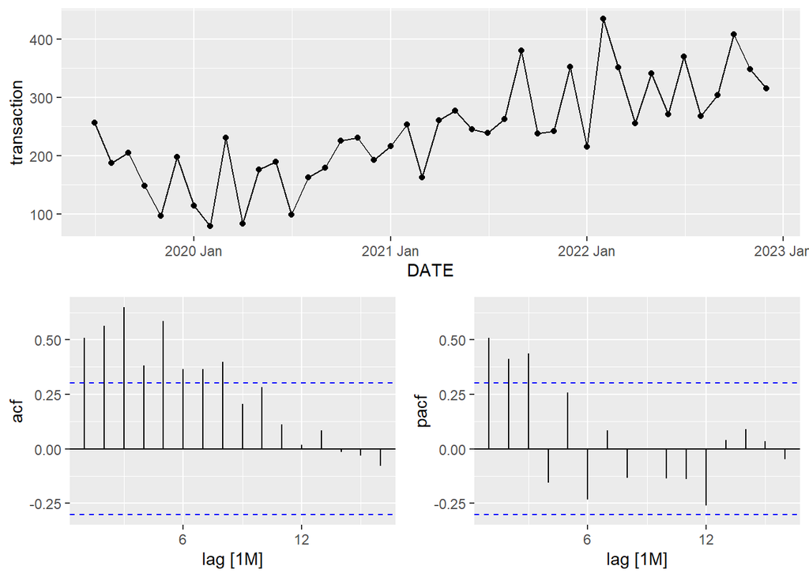

```r
manu_fmcg_monthly_tsibble |> filter(!is.na(transaction)) |>                                                                                gg_tsdisplay(transaction,plot_type = "partial")
```

##decompostion for the original data

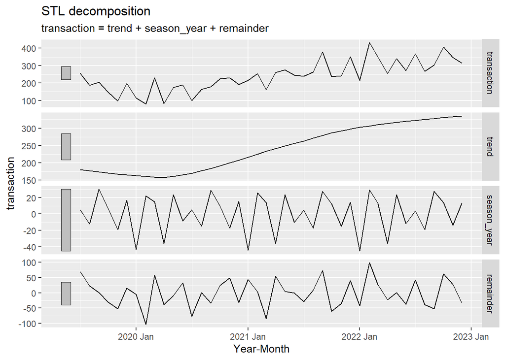

```r
monthly_dcmp <- manu_fmcg_monthly_tsibble |> filter(!is.na(transaction)) |>
                model(stl = STL(transaction))
components(monthly_dcmp) |> autoplot() + labs(x = "Year-Month", y = "transaction")
```

##check the seasonality

```r
Box.test(manu_fmcg_monthly_tsibble$transaction, type = "Ljung-Box")
```

```
##
##  Box-Ljung test
##
## data:  manu_fmcg_monthly_tsibble$transaction
## X-squared = 11.672, df = 1, p-value = 0.0006345
```

##autoarima model

```r
model <- forecast::auto.arima(manu_fmcg_monthly_tsibble, stepwise = FALSE, approximation = FALSE, seasonal = TRUE)
```

##summary of that model

```r
summary(model)
```

```
## Series: manu_fmcg_monthly_tsibble
## ARIMA(2,1,0)(1,0,0)[12]
##
## Coefficients:
##           ar1      ar2     sar1
##       -0.9249  -0.5523  -0.3537
## s.e.   0.1255   0.1256   0.1717
##
## sigma^2 = 3029:  log likelihood = -222.34
## AIC=452.67   AICc=453.78   BIC=459.53
##
## Training set error measures:
##                    ME    RMSE      MAE       MPE     MAPE     MASE         ACF1
## Training set 8.373443 52.3515 40.08884 -2.267692 18.48982 0.442327 -0.003531046
```

AR: yt - yt-1 = φ1(yt-1 - yt-2) + φ2(yt-2 - yt-3) + et et = yt - yt-1 - φ1(yt-1 - yt-2) - φ2(yt-2 - yt-3)

SAR[12]: yt = et - Φ1B12yt yt = et - Φ1 yt-12  
et = yt + Φ1 yt-12

Expaination of this model: (1 - φ1B - φ2B2)(1 - B)(1 - Φ1B12)yt = et φ1：-0.9249 φ2：-0.5523 Φ1：-0.3537 This is our prediction function! This type CANNOT be transformed to ETS

##summary model for arima 210

```r
#model_1 <- ARIMA(manu_fmcg_monthly_tsibble, order = c(2,1,0))
model_1 <- arima(manu_fmcg_monthly_tsibble$transaction , order = c(2,1,0))
model_1
```

```
##
## Call:
## arima(x = manu_fmcg_monthly_tsibble$transaction, order = c(2, 1, 0))
##
## Coefficients:
##           ar1      ar2
##       -0.9147  -0.5744
## s.e.   0.1269   0.1241
##
## sigma^2 estimated as 3187:  log likelihood = -224.16,  aic = 454.31
```

##Confidence Interval for Forecast

```r
forecast_arima <- forecast(forecast::auto.arima(manu_fmcg_monthly_tsibble, stepwise = FALSE, approximation = FALSE, seasonal = TRUE), h = 24)
forecast_arima
```

```
##          Point Forecast    Lo 80    Hi 80    Lo 95    Hi 95
## Jan 2023       390.2214 319.6875 460.7553 282.3491 498.0937
## Feb 2023       284.6388 213.9064 355.3713 176.4629 392.8148
## Mar 2023       325.0023 249.4063 400.5983 209.3883 440.6164
## Apr 2023       364.2830 277.3455 451.2205 231.3235 497.2425
## May 2023       322.9356 234.5220 411.3492 187.7186 458.1526
## Jun 2023       355.0248 261.0190 449.0305 211.2554 498.7942
## Jul 2023       319.5221 220.1846 418.8595 167.5986 471.4455
## Aug 2023       351.9698 249.9599 453.9797 195.9592 507.9804
## Sep 2023       342.8266 236.1096 449.5437 179.6170 506.0363
## Oct 2023       304.7467 194.2300 415.2634 135.7260 473.7674
## Nov 2023       325.0898 211.4058 438.7738 151.2251 498.9545
## Dec 2023       338.2101 220.6297 455.7905 158.3864 518.0338
## Jan 2024       310.6915 193.0701 428.3128 130.8052 490.5777
## Feb 2024       348.1087 227.6186 468.5988 163.8350 532.3824
## Mar 2024       334.2614 212.1717 456.3510 147.5413 520.9814
## Apr 2024       319.9305 197.1580 442.7030 132.1662 507.6948
## May 2024       334.7223 209.8606 459.5841 143.7628 525.6819
## Jun 2024       323.4591 197.3900 449.5282 130.6531 516.2652
## Jul 2024       335.8440 208.6441 463.0439 141.3086 530.3795
## Aug 2024       324.4787 195.6661 453.2913 127.4769 521.4806
## Sep 2024       327.7048 197.7163 457.6933 128.9046 526.5050
## Oct 2024       341.1196 209.8593 472.3798 140.3743 541.8648
## Nov 2024       333.9787 201.3374 466.6200 131.1213 536.8361
## Dec 2024       329.3175 195.4791 463.1558 124.6294 534.0056
```

##Create teh prediction graph

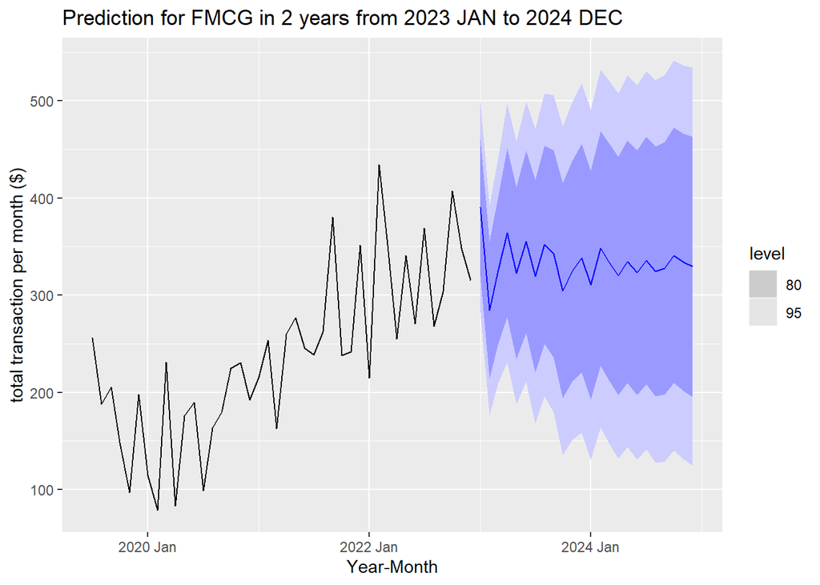

```r
manu_fmcg_monthly_tsibble |>
    model(auto_arima = ARIMA(transaction ~ pdq(2,1,0) + PDQ(1,0,0,12))) |>
    forecast(h = 24) |>
    autoplot(manu_fmcg_monthly_tsibble) +
    labs(
         title = "Prediction for FMCG in 2 years from 2023 JAN to 2024 DEC",
         x = "Year-Month",
         y = "total transaction per month ($)",
         )
```

##write the data out for python

```r
# Export data to a CSV file using write.table
file_path <- "C:\\Users\\guoyy\\OneDrive\\Desktop\\Program\\Mars_petcare\\me\\ts_cv.csv"
write.table(manu_fmcg_monthly_tsibble,
            file = file_path,
            sep = ",", col.names = TRUE, row.names = FALSE)
```

##add some comparision based on AIC

```r
arima_fit <- manu_fmcg_monthly_tsibble |>
             filter(!is.na(transaction)) |>
             model(
                   arima110 = ARIMA(transaction ~ pdq(1,1,0)),
                   arima013 = ARIMA(transaction ~ pdq(0,1,3)),
                   arima011 = ARIMA(transaction ~ pdq(0,1,1)),
                   arima210 = ARIMA(transaction ~ pdq(2,1,0) + PDQ(0,0,0,12)),
                   SARIMA   = ARIMA(transaction ~ pdq(2,1,0) + PDQ(1,0,0,12))
                   )
#here you should be careful that the arima will automatically generate the seasonal part itself
arima_fit
```

```
## # A mable: 1 x 5
##                    arima110                           arima013
##                     <model>                            <model>
## 1 <ARIMA(1,1,0)(1,0,0)[12]> <ARIMA(0,1,3)(0,0,1)[12] w/ drift>
## # ℹ 3 more variables: arima011 <model>, arima210 <model>, SARIMA <model>
```

```r
glance(arima_fit) |> arrange(AICc) |> dplyr::select(.model:BIC)
```

```
## # A tibble: 5 × 6
##   .model   sigma2 log_lik   AIC  AICc   BIC
##   <chr>     <dbl>   <dbl> <dbl> <dbl> <dbl>
## 1 SARIMA    3029.   -222.  453.  454.  460.
## 2 arima210  3351.   -224.  454.  455.  459.
## 3 arima013  3008.   -222.  456.  458.  466.
## 4 arima011  3796.   -227.  460.  461.  465.
## 5 arima110  4306.   -230.  466.  467.  471.
```

```r
ets_model <- forecast::ets(manu_fmcg_monthly_tsibble$transaction, restrict = TRUE)
print(ets_model)
```

```
## ETS(A,Ad,N)
##
## Call:
##  forecast::ets(y = manu_fmcg_monthly_tsibble$transaction, restrict = TRUE)
##
##   Smoothing parameters:
##     alpha = 0.0933
##     beta  = 0.0931
##     phi   = 0.8173
##
##   Initial states:
##     l = 275.4998
##     b = -43.6406
##
##   sigma:  60.4004
##
##      AIC     AICc      BIC
## 508.1422 510.5422 518.5682
```

```r
forecast_ets <- forecast(ets_model, h = 24)
forecast_ets
```

```
##    Point Forecast    Lo 80    Hi 80     Lo 95    Hi 95
## 43       336.2160 258.8098 413.6222 217.83339 454.5985
## 44       338.0080 259.4989 416.5170 217.93869 458.0772
## 45       339.4725 258.9426 420.0025 216.31260 462.6325
## 46       340.6695 257.2247 424.1144 213.05166 468.2874
## 47       341.6478 254.5159 428.7797 208.39108 474.9046
## 48       342.4474 251.0163 433.8784 202.61567 482.2791
## 49       343.1009 246.9190 439.2828 196.00336 490.1984
## 50       343.6350 242.3917 444.8782 188.79681 498.4731
## 51       344.0715 237.5717 450.5712 181.19412 506.9488
## 52       344.4282 232.5663 456.2902 173.35013 515.5063
## 53       344.7198 227.4572 461.9823 165.38221 524.0574
## 54       344.9581 222.3056 467.6106 157.37726 532.5389
## 55       345.1528 217.1559 473.1498 149.39835 540.9073
## 56       345.3120 212.0401 478.5839 141.49026 549.1338
## 57       345.4421 206.9809 483.9033 133.68400 557.2002
## 58       345.5485 201.9937 489.1032 126.00034 565.0966
## 59       345.6354 197.0884 494.1823 118.45242 572.8183
## 60       345.7064 192.2714 499.1413 111.04784 580.3649
## 61       345.7644 187.5459 503.9829 103.79014 587.7387
## 62       345.8119 182.9133 508.7105  96.67996 594.9438
## 63       345.8506 178.3731 513.3281  89.71589 601.9854
## 64       345.8823 173.9242 517.8404  82.89508 608.8696
## 65       345.9082 169.5645 522.2520  76.21373 615.6027
## 66       345.9294 165.2914 526.5674  69.66740 622.1914
```

##creating autoplot of ets prediction

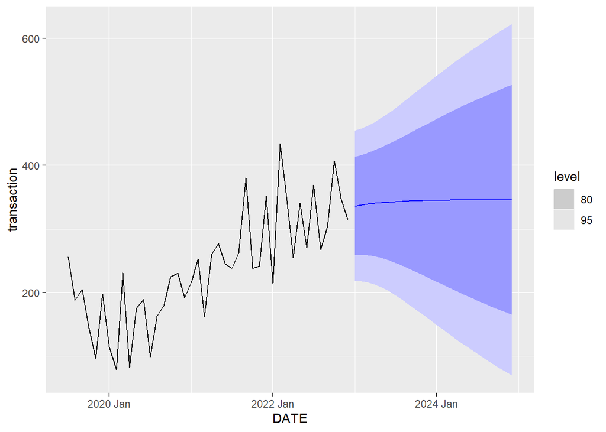

```r
fit <- manu_fmcg_monthly_tsibble |>
      model(ETS(transaction ~ error("A") + trend("Ad") + season("N")))
fc <- fit |>
      forecast(h = 24)
fc |>
  autoplot(manu_fmcg_monthly_tsibble)
```

```r
#together we have the con interval on the above
```